# Step 2 perfomance tests

2019-09-28

1. Build List with vectors which shall be varied

N.it <- 1000

V.list <- list(n.Fast = c(0, 1000, 3000, 10000), n.Medium = c(0, 1000, 3000, 10000), n.Slow1 = c(0, 3000, 10000), n.Slow2 = c(10000, 30000, 100000), Background = c(0, 20, 40), Channels = c(100, 400), Channel.width = c(0.1, 0.2, 0.5), Algorithm = c(1, 2, 3))

V.list <- list(n.Fast = c(0, 1000, 10000), n.Medium = c(0, 1000), n.Slow1 = c(0, 3000), n.Slow2 = c(30000), Background = c(0), Channels = c(100, 400), Channel.width = c(0.1, 0.5), Algorithm = c(1, 2, 3))

V.list <- list(n.Fast = c(0, 1000, 3000), n.Medium = c(0, 1000,3000), n.Slow1 = c(0, 3000), n.Slow2 = c(30000), Background = c(0,30), Channels = c(100, 400), Channel.width = c(0.1, 0.5), Algorithm = c(1, 2, 3))

```r
# How many iteration per case?
N.it <- 1000

lambda <- c(Fast = 2, Medium = 0.5, Slow1 = 0.1, Slow2 = 0.02)
X <- 1:length(lambda)

V.list <- list(n.Fast = c(0, 1000, 3000, 10000),
               n.Medium = c(0, 1000, 3000, 10000),
               n.Slow1 = c(0, 3000, 10000),
               n.Slow2 = c(10000, 30000, 100000),
               Background = c(0, 20, 40),
               Channels = c(100, 400),
               Channel.width = c(0.1, 0.2, 0.5),
               Algorithm = c(1, 2, 3))

string.Alg <- c("det","nls","det+nls")
V.max <- NULL

for (i in 1:length(V.list)) {
  V.max <- c(V.max, length(V.list[[i]]))
}

N <- prod(V.max)

# time estimation
# prefactor: 6x @ notebook; 3x at Uni PC
print(paste0(" ~ ", 6*N*N.it/10000, " min"))
```

```
[1] " ~ 4665.6 min"
```

2. Cycle through all combinations and build a parameter set for each

```r
V.i <- rep(1, length(V.list))
V.table <- data.frame(NULL)

for (j in 1:N) {

  V <- NULL

  for (i in 1:length(V.list)) {

    if(V.i[i] > V.max[i]) {
      V.i[i] <- 1
      V.i[i + 1] <- V.i[i + 1] + 1
    }

    V <- c(V, V.list[[i]][V.i[i]])

  }

  V.i[1] <- V.i[1] + 1

  V.table <- rbind(V.table, V)
}

colnames(V.table) <- names(V.list)
```

3. Simulation

```r
#  message=FALSE, warning=FALSE

Time.needed <- Sys.time()

C.list <- list(NULL)
Curve <- data.frame(NULL)

for (j in 1:N) {

  #j <- 15

  # Build component table
  V <- V.table[j,]
  C.names <- names(lambda)
  C <- data.frame(name = C.names,
                  lambda = lambda,
                  n = c(t(V[X])))
  C <- C[C$n > 0,]

  C <- calc_OSLintervals(C,
                         channel.width = V$Channel.width,
                         channel.number = V$Channels,
                         verbose = FALSE)

  C.list[[j]] <- list(NULL)
  C.list[[j]]$input <- C
  C.list[[j]]$parameter <- V

  # ...

  R.table <- data.frame(NULL)

  for (i in 1:N.it) {

      R <- data.frame(Fast.n = NA, Fast.sigma = NA, Fast.inside = NA,
                  Medium.n = NA, Medium.sigma = NA, Medium.inside = NA,
                  Slow1.n = NA, Slow1.sigma = NA, Slow1.inside = NA,
                  Slow2.n = NA, Slow2.sigma = NA, Slow2.inside = NA,
                  Time = NA, Failed = 1)

    # Simulate input curve
      Curve <-simulate_OSLcurve(C,
                                channel.width = V$Channel.width,
                                channel.number = V$Channels,
                                add.background = V$Background,
                                add.gaussian.noise = sqrt(V$Background),
                                simulate.curve = TRUE)

      time.start <- Sys.time()

      # Decompose
      C.temp <- decompose_OSLcurve(Curve,
                                   C,
                                   algorithm = string.Alg[V$Algorithm],
                                   verbose = FALSE)

      R$Time <- as.numeric(Sys.time() - time.start)

      # Did the fit succeed?
      if (sum(is.na(C.temp$n))==0) {
        R$Failed <- 0

        # Allocate fitting results for each component to result table line
        for (x in 1:length(C.names)) {

          if (sum(C.temp$name==C.names[x])==1) {

             C.line <- C.temp[C.temp$name==C.names[x],]

            R[[paste0(C.names[x],".n")]] <- C.line$n
            R[[paste0(C.names[x],".sigma")]] <- C.line$n.error


            # is the true value located inside the error bars?
            if (abs(C[C$name==C.names[x],]$n - C.line$n) < C.line$n.error) {

              R[[paste0(C.names[x],".inside")]] <- 1
            } else {

              R[[paste0(C.names[x],".inside")]] <- 0
            }
          }
        }


      }


      R.table <- rbind(R.table, R)
  }


 C.list[[j]]$output <- R.table
}

Time.needed <- Sys.time() - Time.needed
print(Time.needed)
```

[output not shown]

3min for 100*100 calculations

4. Summarize output and put into one big table

```r
S.table <- data.frame(NULL)

for (j in 1:N) {

  S <- C.list[[j]][["output"]]
  V <- C.list[[j]][["input"]]

  S.line <- data.frame(K = nrow(V),
                       Time = mean(S$Time, na.rm = TRUE),
                       Failed = sum(S$Failed, na.rm = TRUE))

  for (i in 1:length(C.names)) {

    S.n <- NA
    S.sigma <- NA

   S.name <- C.names[i]

   if (sum(V$name==S.name)==1) {
     S.n <- S[[paste0(S.name, ".n")]] / V$n[V$name==S.name]
     S.sigma <- S[[paste0(S.name, ".sigma")]] / V$n[V$name==S.name]
   }


   S.component <- data.frame(mea = mean(S.n, na.rm = TRUE),
                             err = sd(S.n, na.rm = TRUE),
                             s.mea = mean(S.sigma, na.rm = TRUE),
                             s.rat = mean(S.sigma, na.rm = TRUE)/sd(S.n, na.rm = TRUE),
                             inside = sum(S[[paste0(C.names[i], ".inside")]] == 1) /
                               (sum(S[[paste0(C.names[i], ".inside")]] == 1) +
                                  sum(S[[paste0(C.names[i], ".inside")]] == 0)))
   colnames(S.component) <- c(paste0(S.name,".mean"),
                              paste0(S.name,".error"),
                              paste0(S.name,".sigma.mean"),
                              paste0(S.name,".sigma.ratio"),
                              paste0(S.name,".inside"))

   S.line <- cbind(S.line, S.component)
  }


  S.table <- rbind(S.table, S.line)

}

S.table <- cbind(V.table, S.table)
```

4.1 Display one specfic case:

```r
i.Case <- 1234

C <- C.list[[i.Case]]$input
V <- C.list[[i.Case]]$parameter

# Simulate input curve
Curve <-simulate_OSLcurve(C,
                          channel.width = V$Channel.width,
                          channel.number = V$Channels,
                          add.background = V$Background,
                          add.gaussian.noise = sqrt(V$Background),
                          simulate.curve = TRUE)

# Decompose
C.temp <- decompose_OSLcurve(Curve,
                             C,
                             algorithm = string.Alg[V$Algorithm],
                             verbose = TRUE)
```

|  | name | lambda | n | t.start | t.end | ch.start | ch.end | n.error | n.residual | bin | bin.error |
| --- | --- | --- | --- | --- | --- | --- | --- | --- | --- | --- | --- |
| Fast | Fast | 2.00 | 1053.456 | 0.0 | 1.2 | 1 | 6 | 77.34244 | 0 | 2876 | 27.49752 |
| Slow1 | Slow1 | 0.10 | 9863.574 | 1.2 | 9.0 | 7 | 45 | 709.54378 | 1335 | 9607 | 101.35356 |
| Slow2 | Slow2 | 0.02 | 33850.585 | 9.0 | 20.0 | 46 | 100 | 1049.63630 | 22691 | 8259 | 83.79033 |

[output not shown]

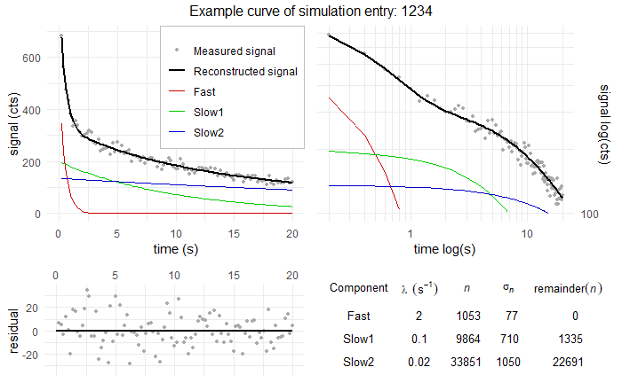

```r
# Plot
plot_OSLcurve(Curve, C.temp, title = paste0("Example curve of simulation entry: ", i.Case))
```

5.1 Time efficiency

```r
O.table <- data.frame(matrix(NA, nrow = 4, ncol = 3))

for (j in 1:3) {
  for (i in 1:4) {
    O.table[i,j] <- mean(S.table[((S.table$K == i) & (S.table$Algorithm == j)),]$Time, na.rm = TRUE) * 1000

  }

}

print(O.table)
```

| X1 | X2 | X3 |
| --- | --- | --- |
| 1.421612 | 1.797707 | 2.969739 |
| 2.159002 | 2.029218 | 3.941796 |
| 2.903167 | 2.318136 | 4.984774 |
| 3.675646 | 2.683041 | 6.118692 |

```r
NA
NA
```

5.2 Accuracy table

```r
TABLE <- S.table[(S.table$Background == 40), ]

print(nrow(TABLE))
```

```
[1] 2592
```

```r
#Col.selection <- seq(12, 27, 5) # means
Col.selection <- seq(16, 31, 5) # inside

O.table <- data.frame(matrix(NA, nrow = 8, ncol = 4))
colnames(O.table) <- colnames(S.table[,Col.selection])
rownames(O.table) <- c("Minimum", "5% percentile", "25% percentile",
                      "Median",
                      "75% percentile", "95% percentile", "Maximum",
                      "Bandwidth")

for (a in V.list$Algorithm) {

  j <- 1
  for (i in Col.selection) {

    O.table[1:7,j] <- quantile(TABLE[(TABLE$Algorithm == a), i],
                               probs = c(0, 0.05, 0.25, 0.5, 0.75, 0.95, 1),
                               na.rm = TRUE)

    O.table[8,j] <- nrow(TABLE[(TABLE$Algorithm == a) &
                                   (TABLE[,i] < 1.1) &
                                   (TABLE[,i] > 0.9) &
                                   !is.na(TABLE[,i]),]) /
      nrow(TABLE[(TABLE$Algorithm == a) &
      !is.na(TABLE[,i]),])

    j <- j + 1
  }

  print(O.table)

}
```

|  | Fast.inside | Medium.inside | Slow1.inside | Slow2.inside |
| --- | --- | --- | --- | --- |
| Minimum | 0.00000 | 0.00000 | 0.00000 | 0.00000 |
| 5% percentile | 0.00000 | 0.00000 | 0.00000 | 0.00000 |
| 25% percentile | 0.45275 | 0.11800 | 0.00000 | 0.00000 |
| Median | 0.62400 | 0.56300 | 0.19750 | 0.00000 |
| 75% percentile | 0.66400 | 0.66025 | 0.63675 | 0.00725 |
| 95% percentile | 0.69000 | 0.69065 | 0.68500 | 0.64070 |
| Maximum | 0.71000 | 0.73300 | 0.70900 | 0.70200 |
| Bandwidth | 0.00000 | 0.00000 | 0.00000 | 0.00000 |

|  | Fast.inside | Medium.inside | Slow1.inside | Slow2.inside |
| --- | --- | --- | --- | --- |
| Minimum | 0.1110 | 0.00400 | 0.0000 | 0.0000 |
| 5% percentile | 0.1634 | 0.08600 | 0.0000 | 0.0000 |
| 25% percentile | 0.2220 | 0.21025 | 0.0050 | 0.0000 |
| Median | 0.2790 | 0.34650 | 0.1580 | 0.0000 |
| 75% percentile | 0.3610 | 0.46400 | 0.5020 | 0.0000 |
| 95% percentile | 0.4840 | 0.58900 | 0.6626 | 0.4046 |
| Maximum | 0.5950 | 0.64700 | 0.7080 | 0.6920 |
| Bandwidth | 0.0000 | 0.00000 | 0.0000 | 0.0000 |

|  | Fast.inside | Medium.inside | Slow1.inside | Slow2.inside |
| --- | --- | --- | --- | --- |
| Minimum | 0.39200000 | 0.05000000 | 0.000000000 | 0.00000 |
| 5% percentile | 0.51235000 | 0.38805000 | 0.000000000 | 0.00000 |
| 25% percentile | 0.59400000 | 0.54975000 | 0.038500000 | 0.00000 |
| Median | 0.64800000 | 0.64350000 | 0.309000000 | 0.00000 |
| 75% percentile | 0.72325000 | 0.72425000 | 0.636250000 | 0.00825 |
| 95% percentile | 0.99000000 | 0.98800000 | 0.747000000 | 0.66465 |
| Maximum | 1.00000000 | 1.00000000 | 1.000000000 | 0.76200 |
| Bandwidth | 0.09567901 | 0.07561728 | 0.005208333 | 0.00000 |

```r
#write.csv(C.table, paste0(path,"/S.table_accuracy.csv"))
```